# Practice with dplyr and ggplot2

### Getting fancy with a map!

When using geom_polygon or geom_map, you will typically need two data frames:

- one contains the coordinates of each polygon (positions)
- the other the values associated with each polygon (values).

An id variable links the two together.

Run the below example code to get map graphs for votes in 2008 and then 2016.

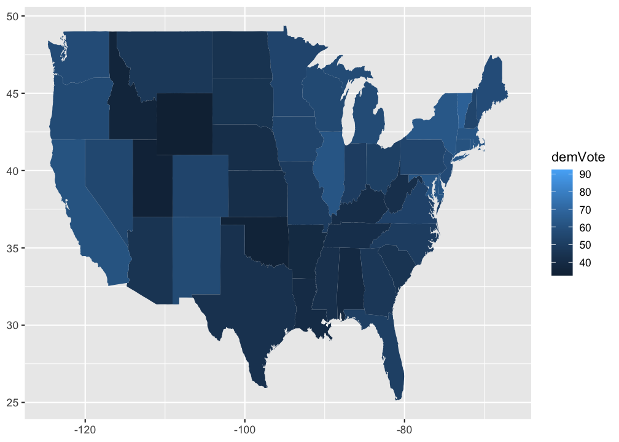

```r
library(maps)
votedata$state <- tolower(votedata$state)  ## states need to be lowercase for linking

states_map <- map_data("state") ## this gives us the lat and long for each point of each state.

map_plot <-  ggplot(data =  votedata %>% filter(year == 2008), aes(map_id = state)) +
    geom_map(aes(fill = demVote), map = states_map) +
    expand_limits(x = states_map$long, y = states_map$lat)

map_plot
```

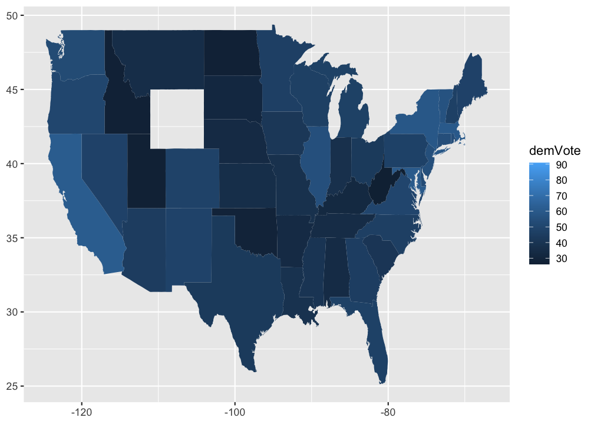

```r
map_plot <-  ggplot(data =  votedata %>% filter(year == 2016), aes(map_id = state)) +
  geom_map(aes(fill = demVote), map = states_map)+
  expand_limits(x = states_map$long, y = states_map$lat)

map_plot
```

```r
## turns out wyoming(?) is missing data for 2016!
```

What if I want a map that shows which of the states are “south”? What do I change?

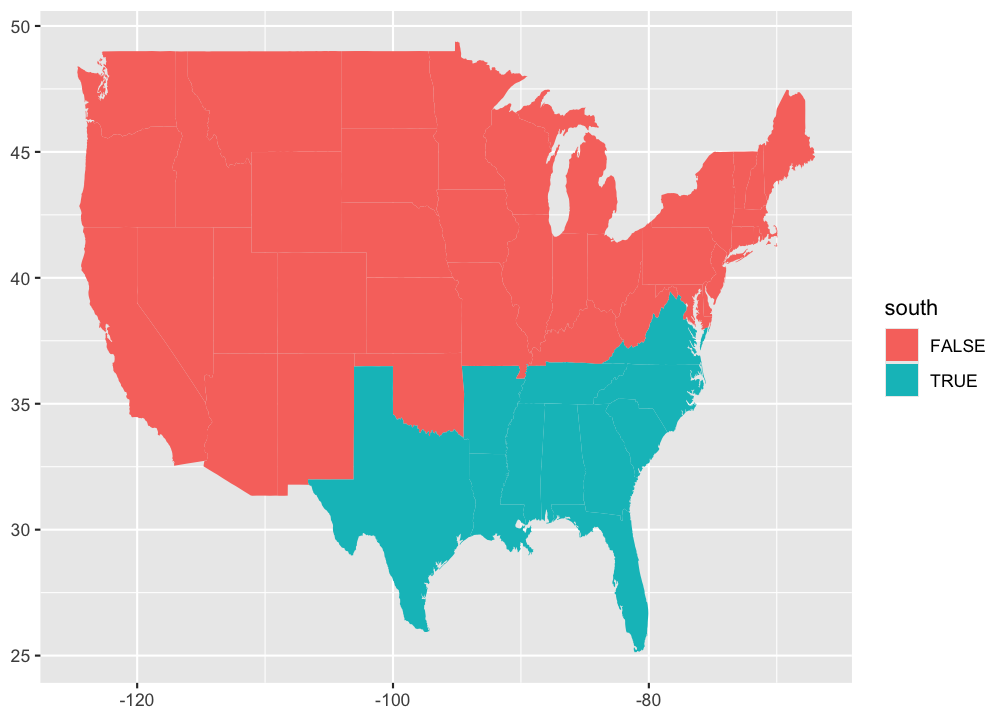

```r
map_plot_states <-  ggplot(data =  votedata %>% filter(year == 2008),
                           aes(map_id = state)) +
  geom_map(aes(fill = south), map = states_map) +
  expand_limits(x = states_map$long, y = states_map$lat)

map_plot_states
```

```r
## changing to 2008 so we fill that gap in, and the year doesn't matter for this
```

### Some more dplyr practice

I want to know the average democratic vote for N vs S, by year.

First, find the average democratic votes for the north and the south, every year. You’ll need to do a *double* `group_by()` here. You do it in one call of the function.

```r
votedata |>
  group_by(year, south) |>
  summarise(avg_dem_vote = mean(demVote))
```

[output not shown]

```
## # A tibble: 44 × 3
## # Groups:   year [22]
##     year south avg_dem_vote
##    <int> <lgl>        <dbl>
##  1  1932 FALSE         56.7
##  2  1932 TRUE          83.4
##  3  1936 FALSE         59.2
##  4  1936 TRUE          83.2
##  5  1940 FALSE         52.8
##  6  1940 TRUE          80.9
##  7  1944 FALSE         51.1
##  8  1944 TRUE          75.1
##  9  1948 FALSE         50.2
## 10  1948 TRUE          45.9
## # ℹ 34 more rows
```

Then, let’s plot that! Pipe the result of your group_by and summarize to ggplot and geom_line(), with year on the x axis and your summarized value on the y axis. Color by the `south` variable.

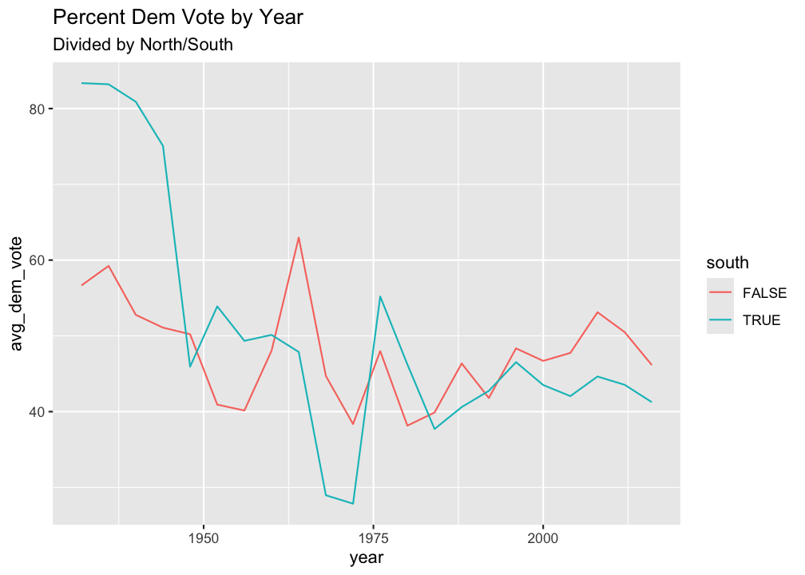

```r
votedata |>
  group_by(year, south) |>
  summarise(avg_dem_vote = mean(demVote),
            .groups = "drop_last") |>
    ## dropping the groups to get rid of a warning
  ggplot(aes(x = year, y = avg_dem_vote, color = south)) +
  geom_line() +
  labs(title = "Percent Dem Vote by Year", subtitle = "Divided by North/South")
```

## More Practice with Penguins

If you’ve made it all the way down here, here are a few extra prompts to try out:

- Count the number of male and female penguins for each species.
- Find the average penguin mass for each island
- Find the average bill length by sex
- Make a plot of bill_length and bill_depth, but only for the female penguins.
- Make a plot of flipper length and body mass, faceted by island and colored by species.
- Plot the density of the flipper length, colored by sex
- Plot the density of the body mass, colored by year

<or, make your own similar graphs with any of the data we’ve used in class so far!>

```r
## a selection of these

# Count the number of male and female penguins for each species.
penguins |> summarise(num_peng = n(), .by = c(species, sex))
```

```
## # A tibble: 8 × 3
##   species   sex    num_peng
##   <fct>     <fct>     <int>
## 1 Adelie    male         73
## 2 Adelie    female       73
## 3 Adelie    <NA>          6
## 4 Gentoo    female       58
## 5 Gentoo    male         61
## 6 Gentoo    <NA>          5
## 7 Chinstrap female       34
## 8 Chinstrap male         34
```

```r
## OR
penguins |> group_by(species, sex) |>  summarise(num_peng = n())
```

[output not shown]

```
## # A tibble: 8 × 3
## # Groups:   species [3]
##   species   sex    num_peng
##   <fct>     <fct>     <int>
## 1 Adelie    female       73
## 2 Adelie    male         73
## 3 Adelie    <NA>          6
## 4 Chinstrap female       34
## 5 Chinstrap male         34
## 6 Gentoo    female       58
## 7 Gentoo    male         61
## 8 Gentoo    <NA>          5
```

```r
## i actually don't mind having the NA values counted here - it's letting us know how many are missing info on sex for each species.

# Find the average penguin mass for each island
penguins |>
  drop_na(body_mass_g) |> # need to remove NA here to compute averages
  group_by(island) |>
  summarise(avg_mass = mean(body_mass_g))
```

```
## # A tibble: 3 × 2
##   island    avg_mass
##   <fct>        <dbl>
## 1 Biscoe       4716.
## 2 Dream        3713.
## 3 Torgersen    3706.
```

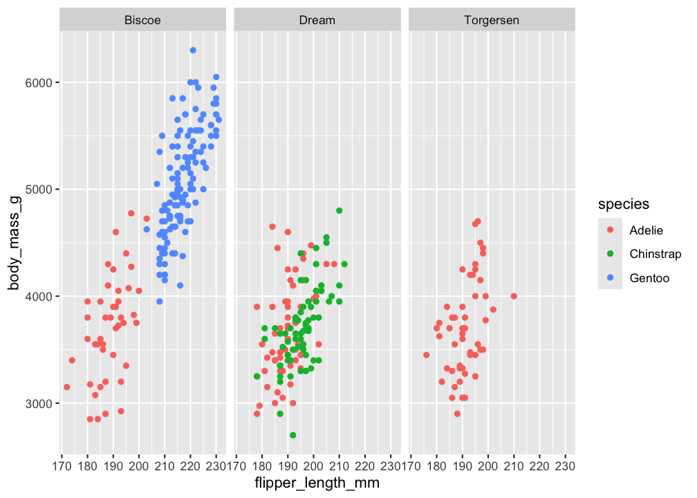

```r
# Make a plot of flipper length and body mass, faceted by island and colored by species.
penguins |>
  drop_na(flipper_length_mm, body_mass_g) |>  ## doesn't change graph, just removes the warning
  ggplot(aes(flipper_length_mm, body_mass_g, colour = species)) +
  geom_point() +
  facet_wrap(~ island)
```

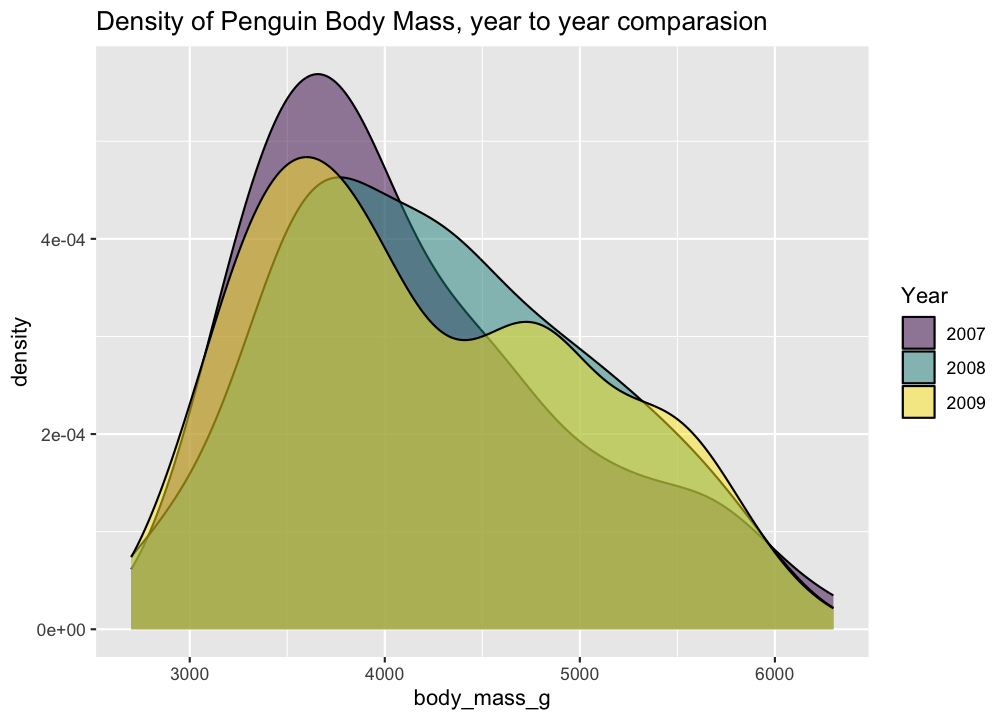

```r
# Plot the density of the body mass, colored by year
penguins |>
  drop_na(body_mass_g) |>
  ggplot(aes(body_mass_g, fill = factor(year, ordered = T))) +
    ## you have to turn year into a factor to color the densities discretely!
    ## i ordered the factor, since they do go in order, but that's not necessary
  geom_density(alpha = 0.5) +
  labs(fill = "Year",
       title = "Density of Penguin Body Mass, year to year comparasion")
```